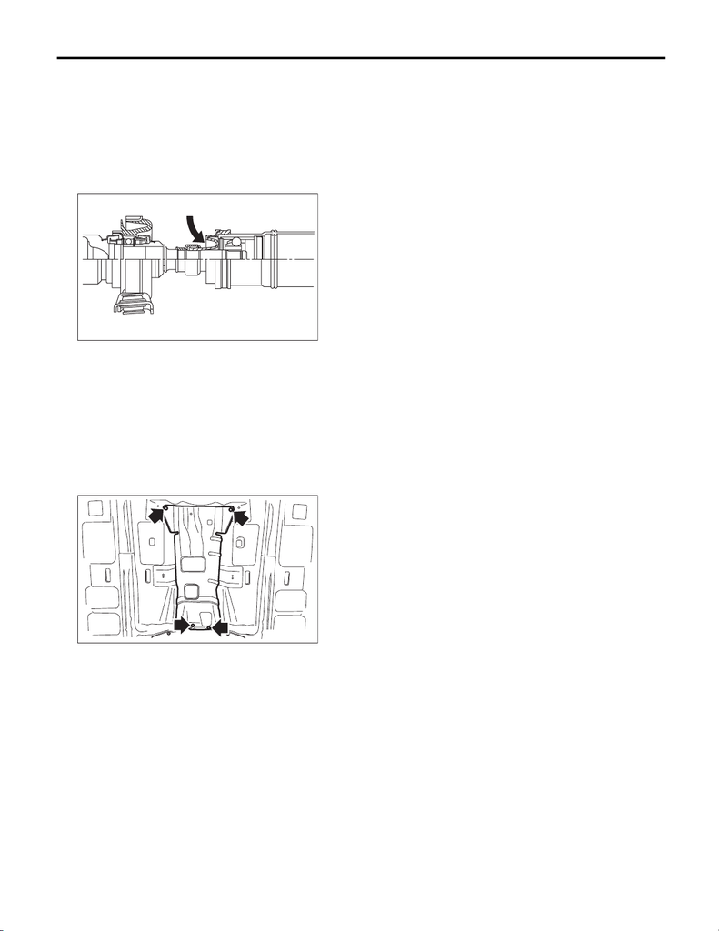

DS-12

Propeller Shaft

DRIVE SHAFT SYSTEM

2. Propeller Shaft

A: REMOVAL

CAUTION:

• Before removing propeller shaft, wrap metal parts with a cloth or rubber material.

• Do not disassemble the center EDJ of the propeller shaft.

• Before removing the propeller shaft, wrap the center joint part with a cloth, etc. If the joint is bent

during removal, the rubber boot may be damaged due to interference with metal parts.

1) Shift the select lever or gear shift lever to neutral.

2) Release the parking brake.

3) Lift up the vehicle.

4) Remove the center exhaust pipe.

• STI model: <Ref. to EX(STI)-7, REMOVAL, Center Exhaust Pipe.>

• Except for STI model: <Ref. to EX(w/o STI)-35, REMOVAL, Center Exhaust Pipe.>

5) Remove the rear exhaust pipe.

• STI model: <Ref. to EX(STI)-12, REMOVAL, Rear Exhaust Pipe.>

• Except for STI model: <Ref. to EX(w/o STI)-50, REMOVAL, Rear Exhaust Pipe.>

6) Remove the bolts to remove the front heat shield cover.

DS-00239

EI-02671

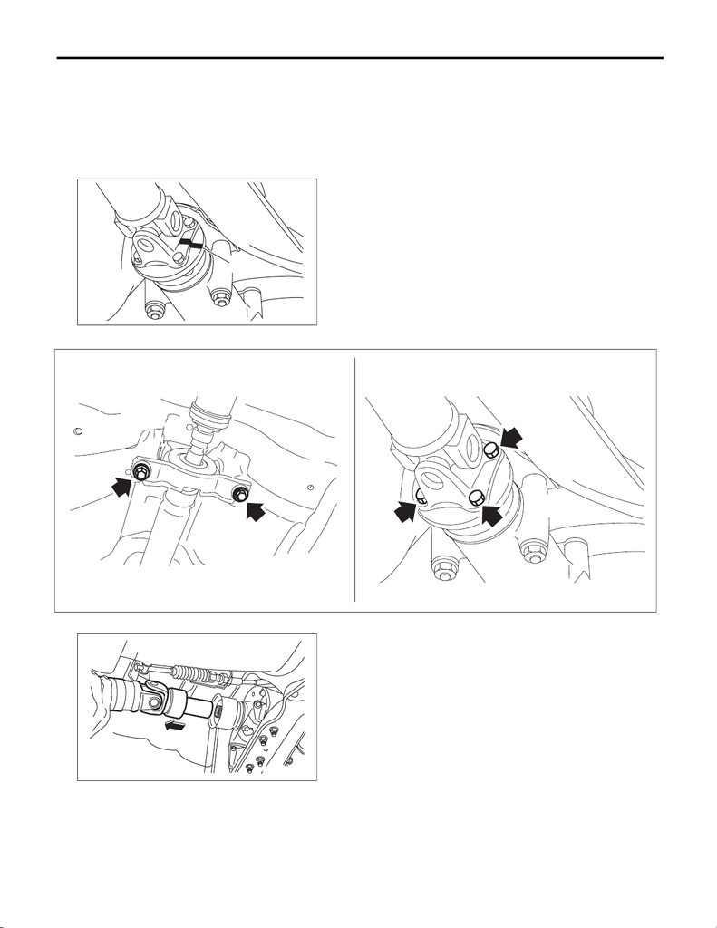

DS-13

Propeller Shaft

DRIVE SHAFT SYSTEM

7) Remove the propeller shaft assembly.

CAUTION:

• Do not disassemble the propeller shaft.

• Use a container to catch ATF or oil flowing from propeller shaft.

• To prevent ATF from leaking, install extension cap etc. to the transmission.

• Be careful not to damage oil seals and contact surface of the sleeve yoke.

(1) Place alignment marks (A) on the flange yoke and rear differential.

(2) Remove the bolts and remove the propeller shaft from the rear differential.

(3) Remove the end of propeller shaft from the transmission.

NOTE:

Use a container to catch oil flowing from propeller shaft.

DS-00028

(A)

DS-00485

DS-00030

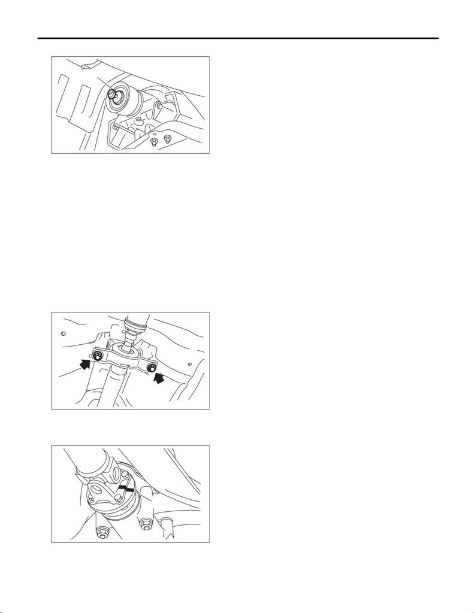

DS-14

Propeller Shaft

DRIVE SHAFT SYSTEM

(4) Install extension cap (A) to the transmission.

NOTE:

If extension cap (A) is not available, place vinyl bag over opening and fasten with string to prevent gear oil

from leaking.

B: INSTALLATION

1) Before installation, check the following items, and replace the propeller shaft assembly as necessary.

• Dents or cracks on the tube surface

• Splines for deformation or abnormal wear

• Unsmooth joint operation or abnormal noise

• Center bearing for free play, noise or non-smooth operation.

• Oil seals for abnormal wear or damage

• Damaged center bearing

2) Apply fluid or gear oil to the oil seal lip and the propeller shaft.

• CVT model: SUBARU CVT OIL FOR LINEARTRONIC

•MT model: GL-5

3) Insert the sleeve yoke into the transmission and attach center bearing to body.

Tightening torque:

52 N·m (5.3 kgf-m, 38.4 ft-lb)

4) Align the alignment marks (A), and connect the yoke flange and rear differential.

Tightening torque:

31 N·m (3.2 kgf-m, 22.9 ft-lb)

DS-00031

(A)

DS-00473

DS-00028

(A)

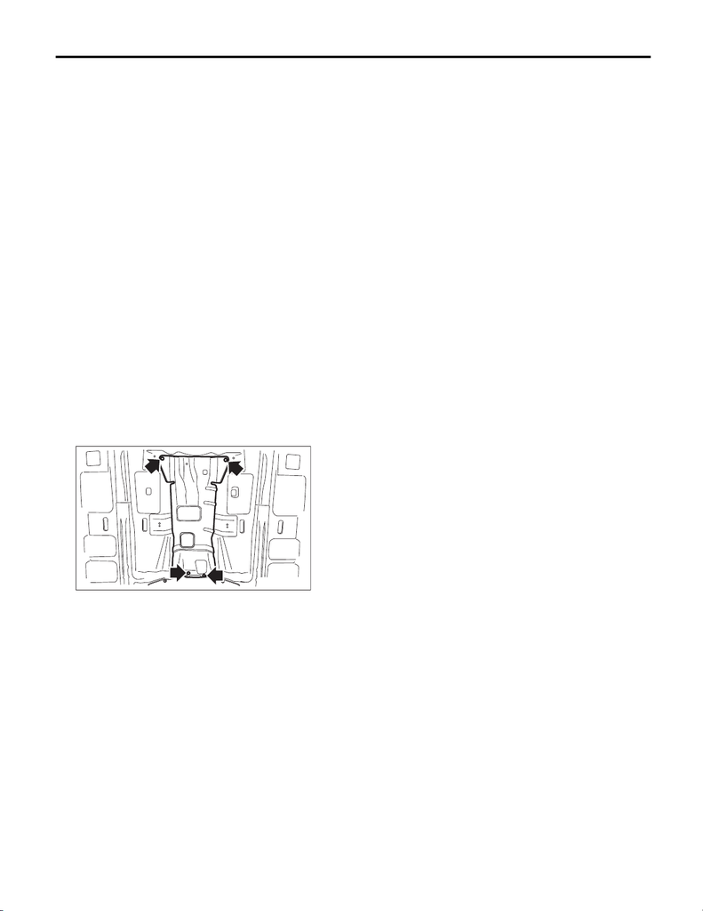

DS-15

Propeller Shaft

DRIVE SHAFT SYSTEM

5) Check the propeller shaft with the propeller shaft installed to the vehicle. <Ref. to DS-15, INSPECTION,

Propeller Shaft.>

6) Install the heat shield cover.

Tightening torque:

18 N·m (1.8 kgf-m, 13.3 ft-lb)

7) Install the rear exhaust pipe.

• STI model: <Ref. to EX(STI)-12, INSTALLATION, Rear Exhaust Pipe.>

• Except for STI model: <Ref. to EX(w/o STI)-51, INSTALLATION, Rear Exhaust Pipe.>

8) Install the center exhaust pipe.

• STI model: <Ref. to EX(STI)-8, INSTALLATION, Center Exhaust Pipe.>

• Except for STI model: <Ref. to EX(w/o STI)-41, INSTALLATION, Center Exhaust Pipe.>

9) Install the under cover - front. <Ref. to EI-22, INSTALLATION, Front Under Cover.>

10) Lower the vehicle.

C: INSPECTION

Check the propeller shaft with the propeller shaft installed to the vehicle.

1) Shift the select lever or gear shift lever to neutral.

2) Release the parking brake.

3) Lift up the vehicle.

4) Remove the center exhaust pipe.

• STI model: <Ref. to EX(STI)-7, REMOVAL, Center Exhaust Pipe.>

• Except for STI model: <Ref. to EX(w/o STI)-35, REMOVAL, Center Exhaust Pipe.>

5) Remove the rear exhaust pipe.

• STI model: <Ref. to EX(STI)-12, REMOVAL, Rear Exhaust Pipe.>

• Except for STI model: <Ref. to EX(w/o STI)-50, REMOVAL, Rear Exhaust Pipe.>

6) Remove the bolts to remove the front heat shield cover.

EI-02671

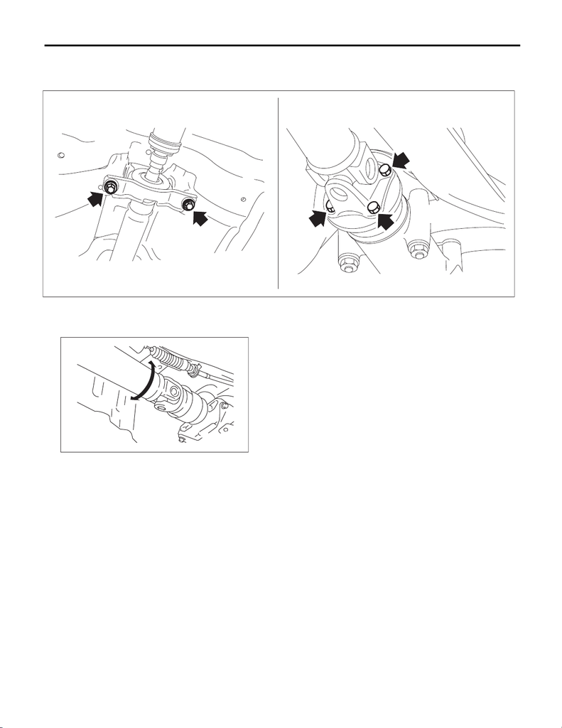

DS-16

Propeller Shaft

DRIVE SHAFT SYSTEM

7) Check the propeller shaft mounting bolt for looseness.

(1) Yoke flange mounting bolts which connect to the rear differential

(2) Center bearing bracket mounting bolts

8) Check the spline and bearing for the propeller shaft.

(1) Turn the propeller shaft by hand to check if abnormal free play exists at splines.

(2) Also move yokes to check if abnormal free play exists at spiders and bearings.

DS-00485

DS-00035

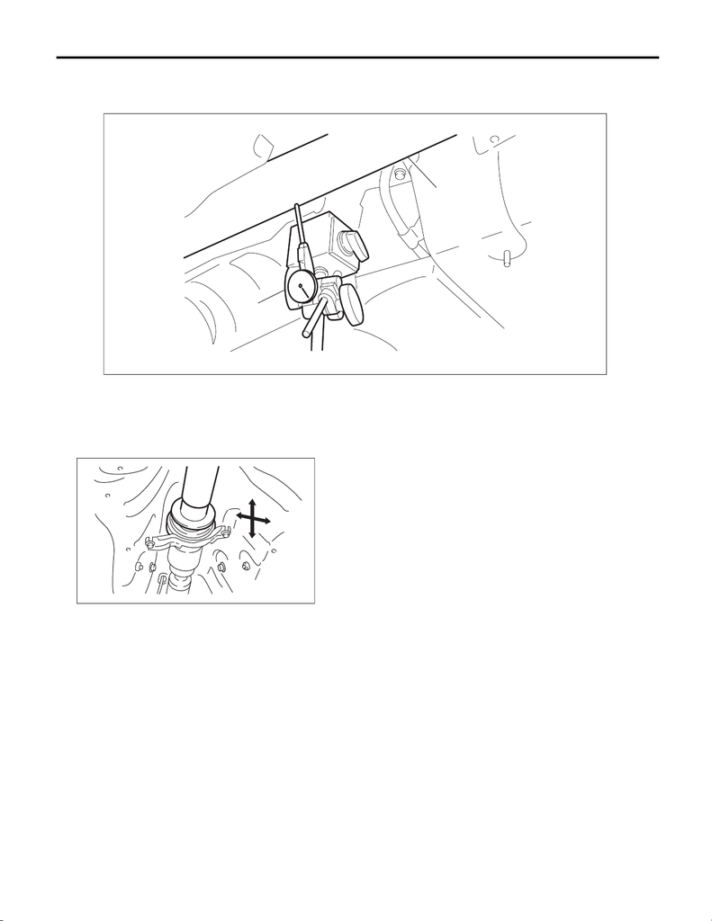

DS-17

Propeller Shaft

DRIVE SHAFT SYSTEM

9) Measure the deflection of the propeller shaft.

(1) Set the dial gauge (B) with its indicator stem at the center of the propeller shaft (A).

(2) Turn the propeller shaft (A) slowly by hands to check for runout of the propeller shaft.

Runout:

Limit: 0.6 mm (0.024 in)

10) Check the center bearing for free play.

Move the propeller shaft near the center bearing up, down, left, right by hand, to check for any abnormal free

play of the bearings.

11) Replace the propeller shaft assembly if faulty is found in the inspection.

DS-00484

(B)

(A)

DS-00037